# Sensitivity Analysis of Humic Acid Assumptions Zn BLM

Cecilia Albert-Black

# Objectives

To assess BLM’s assumption of humic acid content (HA) of dissolved organic carbon (DOC), we will assess bioavailability across a range of HA % 10-60 by increments of 10.

# 1. Setup

Set working directory

```r
setwd("C:/Users/q4q/OneDrive - Oak Ridge National Laboratory/Research/Bioavailability Project/Trace-element-bioavailability-spatial-assessment/Zinc/7. Sensitivity analyses")
```

Import the dataset with BLM results under varying HA (%) and the Bioavailability Master Spreadsheet 3 which contains Typologies

```r
library(readxl)

ha_dat <- read_excel("C:/Users/q4q/OneDrive - Oak Ridge National Laboratory/Research/Bioavailability Project/Trace-element-bioavailability-spatial-assessment/Zinc/3. Dataset cleaning/Bioavailability_Master_Spreadsheet_Clean.xlsx",
    sheet = "HA 10-60%")

head(ha_dat)
```

```
## # A tibble: 6 × 5
##   Sample_ID HA_content TBL_Zn_mol_kg TBL_Zn_nmol_g TBL_Zn_umol_g
##   <chr>          <dbl>         <dbl>         <dbl>         <dbl>
## 1 WaDE_62           10      1.68e-13   0.000000168      1.68e-10
## 2 WaDE_63           10      1.83e-13   0.000000183      1.83e-10
## 3 WaDE_64           10      3.17e-12   0.00000317       3.17e- 9
## 4 WaDE_65           10      2.19e-13   0.000000219      2.19e-10
## 5 WaDE_66           10      4.31e-13   0.000000431      4.31e-10
## 6 WaDE_67           10      1.66e-12   0.00000166       1.66e- 9
```

```r
bms <- read_excel("C:/Users/q4q/OneDrive - Oak Ridge National Laboratory/Research/Bioavailability Project/Trace-element-bioavailability-spatial-assessment/Zinc/5. Cluster analysis/Bioavailability_Master_Spreadsheet_Clean3.xlsx")

head(bms)
```

```
## # A tibble: 6 × 293
##   Sample_ID Site    Date                Regime    Flow_state Network Elevation_m
##   <chr>     <chr>   <dttm>              <chr>     <chr>      <chr>         <dbl>
## 1 WaDE_62   MTN1.1  2023-06-23 00:00:00 NonPeren… Flowing    MTN            248.
## 2 WaDE_63   EFK13.8 2023-06-23 00:00:00 Perennial Flowing    EFK            245.
## 3 WaDE_64   MTN4    2023-06-23 00:00:00 Perennial Flowing    MTN            277.
## 4 WaDE_65   MTN2    2023-06-23 00:00:00 NonPeren… Pooled     MTN            257.
## 5 WaDE_66   MCA3.3  2023-06-23 00:00:00 NonPeren… Flowing    MCA            280.
## 6 WaDE_67   MCA3.2  2023-06-23 00:00:00 NonPeren… Flowing    MCA            275.
## # ℹ 286 more variables: Relative_elevation_m <dbl>,
## #   Upstream_from_main_stem_km <dbl>, Developed_lulc <dbl>, Type <chr>,
## #   Development <chr>, Relative_elevation <chr>, pH <dbl>, Temp_C <dbl>,
## #   DOC_uM <dbl>, Ca_uM <dbl>, Mg_uM <dbl>, Na_uM <dbl>, K_uM <dbl>,
## #   SO4_uM <dbl>, Cl_uM <dbl>, DIC_uM <dbl>, Zn_uM <dbl>, Cu_uM <dbl>,
## #   Free_Zn_M <dbl>, ZnOH_M <dbl>, Zn_OH_2_M <dbl>, ZnCO3_M <dbl>,
## #   ZnHCO3_M <dbl>, ZnSO4_M <dbl>, ZnCl_M <dbl>, ZnS_M <dbl>, …
```

Add Typology column from bms to ha_dat to sample IDs retained in bms

```r
library(dplyr)
#------------------------------------------------------------
# 1. Check whether both datasets contain the same Sample_ID values
#------------------------------------------------------------

# Unique Sample_IDs in each dataset
ha_ids  <- ha_dat %>% distinct(Sample_ID)
bms_ids <- bms %>% distinct(Sample_ID)

# Sample_IDs in ha_dat but not in bms
ha_not_in_bms <- ha_ids %>%
  anti_join(bms_ids, by = "Sample_ID")

# Sample_IDs in bms but not in ha_dat
bms_not_in_ha <- bms_ids %>%
  anti_join(ha_ids, by = "Sample_ID")

# Sample_IDs in ha_dat not in bms, likely filtered out
nrow(ha_not_in_bms)
```

```
## [1] 0
```

```r
ha_not_in_bms
```

```
## # A tibble: 0 × 1
## # ℹ 1 variable: Sample_ID <chr>
```

```r
#------------------------------------------------------------
# 2. Omit samples in ha_dat that do not appear in bms
#------------------------------------------------------------
ha_dat <- ha_dat %>%
  semi_join(bms %>% distinct(Sample_ID), by = "Sample_ID")

#------------------------------------------------------------
# 3. Add Typology from bms to ha_dat by Sample_ID
#------------------------------------------------------------
ha_dat <- ha_dat %>%
  left_join(
    bms %>%
      dplyr::select(Sample_ID, Typology) %>%
      distinct(),
    by = "Sample_ID"
  )

# View result
str(ha_dat)
```

```
## tibble [2,316 × 6] (S3: tbl_df/tbl/data.frame)
##  $ Sample_ID    : chr [1:2316] "WaDE_62" "WaDE_63" "WaDE_64" "WaDE_65" ...
##  $ HA_content   : num [1:2316] 10 10 10 10 10 10 10 10 10 10 ...
##  $ TBL_Zn_mol_kg: num [1:2316] 1.68e-13 1.83e-13 3.17e-12 2.19e-13 4.31e-13 ...
##  $ TBL_Zn_nmol_g: num [1:2316] 1.68e-07 1.83e-07 3.17e-06 2.19e-07 4.31e-07 ...
##  $ TBL_Zn_umol_g: num [1:2316] 1.68e-10 1.83e-10 3.17e-09 2.19e-10 4.31e-10 ...
##  $ Typology     : chr [1:2316] "Developed Perennial" "Perennial" "Perennial" "Pooled" ...
```

```r
head(ha_dat)
```

```
## # A tibble: 6 × 6
##   Sample_ID HA_content TBL_Zn_mol_kg TBL_Zn_nmol_g TBL_Zn_umol_g Typology
##   <chr>          <dbl>         <dbl>         <dbl>         <dbl> <chr>
## 1 WaDE_62           10      1.68e-13   0.000000168      1.68e-10 Developed Pere…
## 2 WaDE_63           10      1.83e-13   0.000000183      1.83e-10 Perennial
## 3 WaDE_64           10      3.17e-12   0.00000317       3.17e- 9 Perennial
## 4 WaDE_65           10      2.19e-13   0.000000219      2.19e-10 Pooled
## 5 WaDE_66           10      4.31e-13   0.000000431      4.31e-10 Non-Perennial
## 6 WaDE_67           10      1.66e-12   0.00000166       1.66e- 9 Non-Perennial
```

# 2. Sensitivity Analysis

Computed differences in TBL-Zn (nmol/g) within each Sample_ID for each incremental increase in HA (%). To do so, first create ha_sens

```r
library(dplyr)

ha_sens <- ha_dat %>%
  arrange(Sample_ID, HA_content) %>%
  group_by(Sample_ID, Typology) %>%

  # Create "next HA" value within each sample
  mutate(
    HA_next = lead(HA_content),
    TBL_next = lead(TBL_Zn_nmol_g)
  ) %>%

  # Keep only valid transitions (drop last HA=80 rows)
  filter(!is.na(HA_next)) %>%

  # Optional: ensure only 10-step increments
  filter(HA_next - HA_content == 10)

# Preview
head(ha_sens)
```

```
## # A tibble: 6 × 8
## # Groups:   Sample_ID, Typology [2]
##   Sample_ID HA_content TBL_Zn_mol_kg TBL_Zn_nmol_g TBL_Zn_umol_g Typology
##   <chr>          <dbl>         <dbl>         <dbl>         <dbl> <chr>
## 1 WaDE_108          10      2.14e-12   0.00000214       2.14e- 9 Main Stem
## 2 WaDE_108          20      2.20e-12   0.00000220       2.20e- 9 Main Stem
## 3 WaDE_108          30      2.25e-12   0.00000225       2.25e- 9 Main Stem
## 4 WaDE_108          40      2.31e-12   0.00000231       2.31e- 9 Main Stem
## 5 WaDE_108          50      2.37e-12   0.00000237       2.37e- 9 Main Stem
## 6 WaDE_122          10      2.54e-13   0.000000254      2.54e-10 Main Stem
## # ℹ 2 more variables: HA_next <dbl>, TBL_next <dbl>
```

## i. Calculate metrics

- **Delta:** absolute change
- **Percent change:** relative change
- **Log response ratio (LRR):** log10(next / current)

```r
ha_sens <- ha_sens %>%
  mutate(
    delta = TBL_next - TBL_Zn_nmol_g,

    pct_change = (TBL_next - TBL_Zn_nmol_g) / TBL_Zn_nmol_g * 100,

    log_rr = log10(TBL_next / TBL_Zn_nmol_g),

    HA_transition = paste0(HA_content, "-", HA_next)
  )

# Preview
head(ha_sens)
```

```
## # A tibble: 6 × 12
## # Groups:   Sample_ID, Typology [2]
##   Sample_ID HA_content TBL_Zn_mol_kg TBL_Zn_nmol_g TBL_Zn_umol_g Typology
##   <chr>          <dbl>         <dbl>         <dbl>         <dbl> <chr>
## 1 WaDE_108          10      2.14e-12   0.00000214       2.14e- 9 Main Stem
## 2 WaDE_108          20      2.20e-12   0.00000220       2.20e- 9 Main Stem
## 3 WaDE_108          30      2.25e-12   0.00000225       2.25e- 9 Main Stem
## 4 WaDE_108          40      2.31e-12   0.00000231       2.31e- 9 Main Stem
## 5 WaDE_108          50      2.37e-12   0.00000237       2.37e- 9 Main Stem
## 6 WaDE_122          10      2.54e-13   0.000000254      2.54e-10 Main Stem
## # ℹ 6 more variables: HA_next <dbl>, TBL_next <dbl>, delta <dbl>,
## #   pct_change <dbl>, log_rr <dbl>, HA_transition <chr>
```

## ii. Summary statistics

Mean and SE of each SA metric by typology by incremental increase in HA (%)

```r
ha_summary <- ha_sens %>%
  group_by(Typology, HA_transition) %>%
  summarise(
    mean_delta = mean(delta, na.rm = TRUE),
    se_delta   = sd(delta, na.rm = TRUE) / sqrt(n()),

    mean_pct_change = mean(pct_change, na.rm = TRUE),
    se_pct_change   = sd(pct_change, na.rm = TRUE) / sqrt(n()),

    mean_log_rr = mean(log_rr, na.rm = TRUE),
    se_log_rr   = sd(log_rr, na.rm = TRUE) / sqrt(n()),

    n = n(),
    .groups = "drop"
  )

head(ha_summary)
```

```
## # A tibble: 6 × 9
##   Typology       HA_transition mean_delta se_delta mean_pct_change se_pct_change
##   <chr>          <chr>              <dbl>    <dbl>           <dbl>         <dbl>
## 1 Developed Per… 10-20           -1.01e-8 6.29e-10           -1.89        0.0886
## 2 Developed Per… 20-30           -9.66e-9 5.96e-10           -1.85        0.0851
## 3 Developed Per… 30-40           -9.26e-9 5.65e-10           -1.81        0.0816
## 4 Developed Per… 40-50           -8.89e-9 5.36e-10           -1.77        0.0783
## 5 Developed Per… 50-60           -8.55e-9 5.10e-10           -1.73        0.0753
## 6 Main Stem      10-20           -1.11e-8 2.10e- 9           -2.51        0.191
## # ℹ 3 more variables: mean_log_rr <dbl>, se_log_rr <dbl>, n <int>
```

```r
# Save
library(openxlsx)

# Define output directory
out_dir <- file.path(getwd(), "Plots of HA SA")

# Create it only if it doesn't exist
if (!dir.exists(out_dir)) {
  dir.create(out_dir)
}

# Create workbook
wb <- createWorkbook()

# Add worksheet
addWorksheet(wb, "HA_Sensitivity_Summary")

# Write data
writeData(wb, "HA_Sensitivity_Summary", ha_summary)

# Save file
saveWorkbook(
  wb,
  file = file.path(out_dir, "HA_Sensitivity_Summary.xlsx"),
  overwrite = TRUE
)
```

Summary across all HA (%) increases

```r
ha_summary_overall <- ha_sens %>%
  group_by(Typology) %>%
  summarise(
    mean_delta = mean(delta, na.rm = TRUE),
    se_delta   = sd(delta, na.rm = TRUE) / sqrt(n()),

    mean_pct_change = mean(pct_change, na.rm = TRUE),
    se_pct_change   = sd(pct_change, na.rm = TRUE) / sqrt(n()),

    mean_log_rr = mean(log_rr, na.rm = TRUE),
    se_log_rr   = sd(log_rr, na.rm = TRUE) / sqrt(n()),

    n = n(),
    .groups = "drop"
  )

head(ha_summary_overall)
```

```
## # A tibble: 5 × 8
##   Typology         mean_delta se_delta mean_pct_change se_pct_change mean_log_rr
##   <chr>                 <dbl>    <dbl>           <dbl>         <dbl>       <dbl>
## 1 Developed Peren…   -9.29e-9 2.54e-10           -1.81        0.0366    -0.00796
## 2 Main Stem          -8.88e-9 9.17e-10           -2.31        0.0786    -0.0103
## 3 Non-Perennial      -1.30e-7 1.46e- 8           -8.78        0.456     -0.0403
## 4 Perennial          -2.10e-8 9.54e-10           -4.66        0.102     -0.0208
## 5 Pooled             -2.62e-8 5.22e- 9           -4.82        0.262     -0.0217
## # ℹ 2 more variables: se_log_rr <dbl>, n <int>
```

```r
# Save
library(openxlsx)

# File path
file_path <- file.path(out_dir, "HA_Sensitivity_Summary.xlsx")

# Load existing workbook
wb <- loadWorkbook(file_path)

if ("Overall_Summary" %in% names(wb)) {
  removeWorksheet(wb, "Overall_Summary")
}

addWorksheet(wb, "Overall_Summary")
writeData(wb, "Overall_Summary", ha_summary_overall)

saveWorkbook(wb, file = file_path, overwrite = TRUE)
```

# 3. Difference in bioavailability at 10 and 60% HA by Typology

Paired t-test and Wilcox signed-rank test (parametric and non-parametric). If both are significant = robust difference.

```r
library(dplyr)
library(tidyr)
library(purrr)

#-------------------------------------------------
# 1. Prepare paired dataset (10% vs 60%)
#-------------------------------------------------
ha_ttest_dat <- ha_dat %>%
  filter(HA_content %in% c(10, 60)) %>%
  mutate(log_tbl_zn = log10(TBL_Zn_nmol_g)) %>%
  dplyr::select(Sample_ID, Typology, HA_content, log_tbl_zn) %>%

  pivot_wider(
    names_from  = HA_content,
    values_from = log_tbl_zn,
    names_prefix = "HA_"
  ) %>%

  # Keep only complete pairs
  filter(!is.na(HA_10), !is.na(HA_60))

#-------------------------------------------------
# 2. Run paired t-test by Typology
#-------------------------------------------------
ttest_results <- ha_ttest_dat %>%
  group_by(Typology) %>%
  summarise(
    # Paired t-test
    t_test = list(t.test(HA_10, HA_60, paired = TRUE)),

    # Wilcoxon paired test
    wilcox_test = list(wilcox.test(HA_10, HA_60, paired = TRUE)),

    mean_10 = mean(HA_10, na.rm = TRUE),
    mean_60 = mean(HA_60, na.rm = TRUE),

    .groups = "drop"
  ) %>%

  mutate(
    t_stat      = map_dbl(t_test, ~ .x$statistic),
    t_p_value   = map_dbl(t_test, ~ .x$p.value),

    w_stat      = map_dbl(wilcox_test, ~ .x$statistic),
    w_p_value   = map_dbl(wilcox_test, ~ .x$p.value)
  ) %>%

  dplyr::select(
    Typology,
    mean_10,
    mean_60,
    t_stat,
    t_p_value,
    w_stat,
    w_p_value
  )

# Save
library(openxlsx)
write.xlsx(
  x = ttest_results,
  file = file.path(out_dir, "HA10-60_t-test.xlsx"),
  overwrite = TRUE
)
```

# 4. Differences in Bioavailability by Typology at 60% HA

Kruskal Wallis test

```r
# Isolate data for HA 60%
ha_60 <- ha_dat %>%
  filter(HA_content == 60) %>%
  mutate(log_tbl_zn = log10(TBL_Zn_nmol_g)) %>%
  filter(!is.na(Typology), !is.na(log_tbl_zn))

kruskal_res <- kruskal.test(log_tbl_zn ~ Typology, data = ha_60)

kruskal_res
```

```
##
##  Kruskal-Wallis rank sum test
##
## data:  log_tbl_zn by Typology
## Kruskal-Wallis chi-squared = 59.232, df = 4, p-value = 4.206e-12
```

Post hoc comparisons

```r
library(dplyr)
library(tibble)
library(agricolae)

alpha <- 0.05

#-------------------------------------------------
# 1. Prepare HA = 60% data
#-------------------------------------------------
ha_60 <- ha_dat %>%
  filter(HA_content == 60) %>%
  mutate(
    log_tbl_zn = log10(TBL_Zn_nmol_g),
    Typology = factor(Typology)
  ) %>%
  filter(!is.na(Typology), !is.na(log_tbl_zn))

#-------------------------------------------------
# 2. Kruskal-Wallis test
#-------------------------------------------------
kw_test <- kruskal.test(log_tbl_zn ~ Typology, data = ha_60)

kw_test
```

```
##
##  Kruskal-Wallis rank sum test
##
## data:  log_tbl_zn by Typology
## Kruskal-Wallis chi-squared = 59.232, df = 4, p-value = 4.206e-12
```

```r
#-------------------------------------------------
# 3. Agricolae Kruskal post-hoc letter groups
#-------------------------------------------------
k_out <- agricolae::kruskal(
  y     = ha_60$log_tbl_zn,
  trt   = ha_60$Typology,
  alpha = alpha,
  group = TRUE
)

#-------------------------------------------------
# 4. Extract grouping letters
#-------------------------------------------------
letters_df <- k_out$groups %>%
  rownames_to_column("Typology") %>%
  rename(Letters = groups)

#-------------------------------------------------
# 5. Combined results table
#-------------------------------------------------
kw_letters_results <- letters_df %>%
  mutate(
    Variable = "log10_TBL_Zn_HA60",
    Chi_sq = as.numeric(kw_test$statistic),
    df = as.numeric(kw_test$parameter),
    p_value = as.numeric(kw_test$p.value)
  ) %>%
  dplyr::select(Variable, Typology, Letters, Chi_sq, df, p_value)


#-------------------------------------------------
# 6. Save
#-------------------------------------------------
library(openxlsx)
file_path <- file.path(out_dir, "KW_test_HA60.xlsx")
write.xlsx(
  x = list(
    "KW_letters" = kw_letters_results,
    "KW_summary" = data.frame(
      test    = kw_test$method,
      variable = "log10_TBL_Zn_HA60",
      chi_sq  = as.numeric(kw_test$statistic),
      df      = as.numeric(kw_test$parameter),
      p_value = kw_test$p.value
    )
  ),
  file = file_path,
  overwrite = TRUE
)
```

# 5. Plots by Typology

Quick re-assignment of letters by Typology at HA=10%

```r
library(dplyr)
library(tibble)
library(purrr)
library(agricolae)

alpha <- 0.05

#-------------------------------------------------
# 1. Post hoc letters at HA = 10 and HA = 60 only
#-------------------------------------------------
ha_letters <- ha_dat %>%
  filter(HA_content %in% c(10, 60)) %>%
  mutate(
    log_tbl_zn = log10(TBL_Zn_nmol_g)
  ) %>%
  filter(!is.na(Typology), !is.na(log_tbl_zn)) %>%
  group_by(HA_content) %>%
  group_modify(~ {

    k_out <- agricolae::kruskal(
      y     = .x$log_tbl_zn,
      trt   = .x$Typology,
      alpha = alpha,
      group = TRUE
    )

    k_out$groups %>%
      rownames_to_column("Typology") %>%
      rename(Letters = groups)
  }) %>%
  ungroup()

#-------------------------------------------------
# 2. Letter positions
#-------------------------------------------------
letter_positions <- ha_dat %>%
  filter(HA_content %in% c(10, 60)) %>%
  mutate(log_tbl_zn = log10(TBL_Zn_nmol_g)) %>%
  group_by(HA_content, Typology) %>%
  summarise(
    y_pos = mean(log_tbl_zn, na.rm = TRUE) +
      sd(log_tbl_zn, na.rm = TRUE) / sqrt(n()) +
      0.05,
    .groups = "drop"
  ) %>%
  left_join(ha_letters, by = c("HA_content", "Typology"))

# Letters positions
offset_map <- c(
  "Pooled" = 0,
  "Perennial" = 0,
  "Developed Perennial" = 0,
  "Non-Perennial" = 0,
  "Main Stem" = 0.02
)

letter_positions <- letter_positions %>%
  mutate(y_offset = offset_map[Typology])
```

Plots

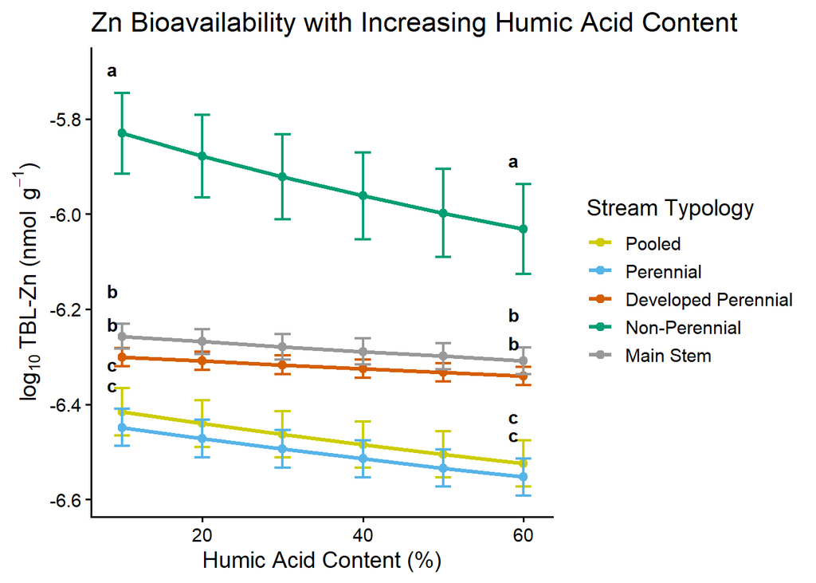

```r
library(ggplot2)
typology_colors <- c(
  "Pooled"    = "yellow3",
  "Perennial" = "#56B4E9",
  "Developed Perennial" = "#D55E00",
  "Non-Perennial" = "#009E73",
  "Main Stem"       = "#999999"
)

# Set order of typologies
ha_dat <- ha_dat %>%
  dplyr::mutate(
    Typology = factor(
      Typology,
      levels = names(typology_colors)
    )
  )

ha_typ <- ggplot(
  ha_dat,
  aes(
    x = HA_content,
    y = log10(TBL_Zn_nmol_g),
    color = Typology
  )
) +

  stat_summary(
    fun = mean,
    geom = "line",
    size = 1.2
  ) +

  stat_summary(
    fun = mean,
    geom = "point",
    size = 2
  ) +

  stat_summary(
    fun.data = mean_se,
    geom = "errorbar",
    width = 2,
    size = 0.8
  ) +

  geom_text(
  data = letter_positions,
  aes(
    x = HA_content,
    y = y_pos + y_offset,   # stagger vertically
    label = Letters
  ),
  position = position_nudge(x = -1.2),  # left shift only
  color = "black",
  show.legend = FALSE,
  size = 4,
  fontface = "bold"
) +

  scale_color_manual(values = typology_colors) +

  labs(
    x = "Humic Acid Content (%)",
    y = expression(log[10]~"TBL-Zn (nmol "~g^{-1}*")"),
    color = "Stream Typology",
    title = "Zn Bioavailability with Increasing Humic Acid Content"
  ) +

  theme_classic(base_size = 14)
# View
ha_typ
```

```r
# Save
ggsave(
  filename = file.path(out_dir, "Zn_by_humic_acid_by_typology.png"),
  plot = ha_typ,
  width = 8,
  height = 5,
  dpi = 600
)
```